# Lab8

Author

Xinran Wang

# **Lab 8 - Efficiency and Parallelization**

```r
library(tidyverse)
library(ggplot2)
library(parallel)
library(cowplot)
library(knitr)
```

# **Learning goals**

In this lab, you are expected to learn/put in practice the following skills:

- Evaluate whether a problem can be parallelized or not.
- Practice with the `parallel` package.

## **Problem 1: Vectorization**

The following functions can be written to be more efficient without using parallelization. Write a faster version of each function and show that (1) the outputs are the same as the slow version, and (2) your version is faster.

1. This function generates an `n x k` dataset with all its entries drawn from a Poission distribution with mean `lambda`.

   ```r
   fun1 <- function(n, k, lambda) {
     x <- NULL

     for (i in 1:n){
       x <- rbind(x, rpois(k, lambda))
     }

     return(x)
   }

   fun1alt <- function(n, k, lambda) {
     # SLOW
     # t(sapply(1:n, function(i){ rpois(k, lambda) }))

     # VERY SLOW
     # res <- mclapply(1:n, function(i){ rpois(k, lambda) })
     # do.call(rbind, res)
     matrix(rpois(n * k, lambda), nrow = n, ncol = k)
   }
   ```

   Show that `fun1alt` generates a matrix with the same dimensions as `fun1` and that the values inside the two matrices follow similar distributions. Then check the speed of the two functions with the following code:

   ```r
   cl <- makeCluster(mc <- getOption("cl.cores", 2))
   clusterSetRNGStream(cl, 123) # to make this reproducible

   set.seed(123)
   df_fun1 <- fun1alt(100, 4, 4)
   set.seed(123)
   df_fun1alt <- fun1alt(100, 4, 4)

   stopCluster(cl)

   print(paste0(
     "dimension of fun1: ", paste(dim(df_fun1), collapse = "x"),
     ", mean: ", round(mean(df_fun1, na.rm = TRUE), 2),
     ", sd: ", round(sd(df_fun1, na.rm = TRUE), 2)))
   ```

   ```
   [1] "dimension of fun1: 100x4, mean: 4.02, sd: 2.03"
   ```

   ```r
   print(paste0(
     "dimension of fun1 alt: ", paste(dim(df_fun1alt), collapse = "x"),
     ", mean: ", round(mean(df_fun1alt, na.rm = TRUE), 2),
     ", sd: ", round(sd(df_fun1alt, na.rm = TRUE), 2)))
   ```

   ```
   [1] "dimension of fun1 alt: 100x4, mean: 4.02, sd: 2.03"
   ```

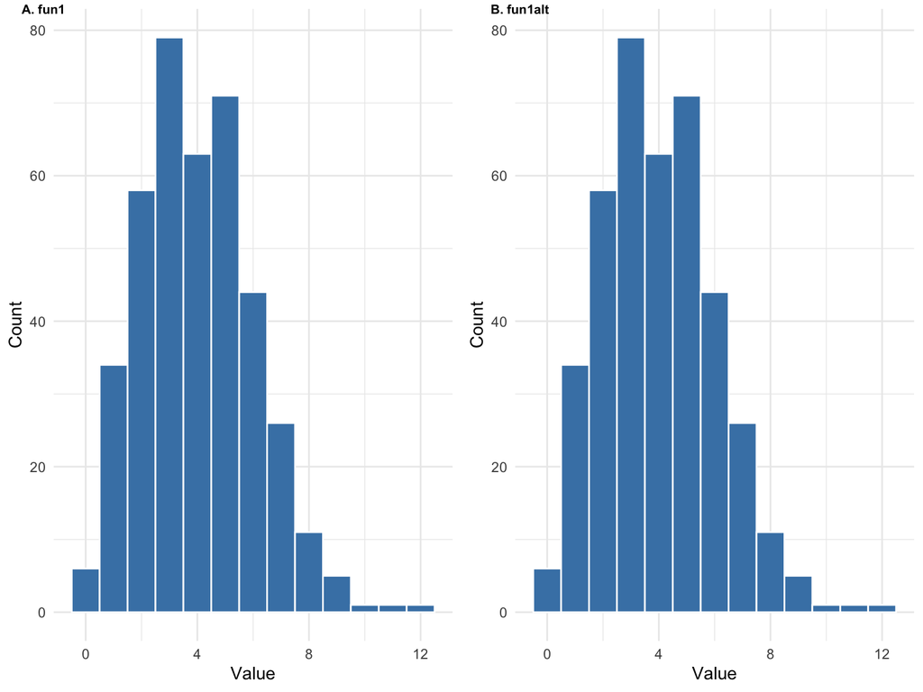

   ```r
   get_histogram <- function(df) {
     df_long <- as.data.frame(df) %>%
       pivot_longer(cols = everything(),
                    names_to = "Variable",
                    values_to = "Value")

     ggplot(df_long, aes(x = Value)) +
       geom_histogram(bins = 50, binwidth = 1, color = "white", fill = "steelblue") +
       labs(
         x = "Value",
         y = "Count"
       ) +
       theme_minimal()
   }

   plot_grid(
     get_histogram(df_fun1),
     get_histogram(df_fun1alt),
     ncol = 2,
     align = "h",
     labels = c("A. fun1", "B. fun1alt"),
     label_size = 8
   )
   ```

   ```r
   # Benchmarking
   #cl <- makeCluster(mc <- getOption("cl.cores", 2))
   cl <- makeCluster((detectCores() - 1))
   clusterSetRNGStream(cl, 123) # to make this reproducible

   microbenchmark <- microbenchmark::microbenchmark(
     fun1(100, 4, 4),
     fun1alt(100, 4, 4)
   )

   microbenchmark
   ```

   ```
   Unit: microseconds
                  expr    min      lq      mean  median     uq      max neval cld
       fun1(100, 4, 4) 91.348 94.7715 110.13543 96.3090 98.728 1375.181   100  a
    fun1alt(100, 4, 4)  9.389  9.7170  10.09051  9.9425 10.250   15.990   100   b
   ```

   ```r
   stopCluster(cl)
   ```

2. This function finds the maximum value of each column of a matrix.

   ```r
   # Data Generating Process (10 x 10,000 matrix)
   set.seed(1234)
   x <- matrix(rnorm(1e4), nrow=10)

   # Find each column's max value
   fun2 <- function(x) {
     apply(x, 2, max)
   }

   library(matrixStats)
   fun2alt <- function(x) {
     colMaxs(as.matrix(x))
     # x[cbind(max.col(t(x)), 1:ncol(x))]
   }
   ```

   Show that both functions return the same output for a given input matrix, `x`. Then check the speed of the two functions, as you did above.

   ```r
   cl <- makeCluster(mc <- getOption("cl.cores", 2))
   clusterSetRNGStream(cl, 123) # to make this reproducible
   stopCluster(cl)

   df_fun2 <- fun2(x)
   df_fun2alt <- fun2alt(x)

   identical(df_fun2, df_fun2alt)
   ```

   ```
   [1] TRUE
   ```

   ```r
   cl <- makeCluster((detectCores() - 1))
   clusterSetRNGStream(cl, 123) # to make this reproducible

   microbenchmark <- microbenchmark::microbenchmark(
     fun2(x),
     fun2alt(x)
   )

   microbenchmark
   ```

   ```
   Unit: microseconds
          expr     min       lq      mean  median      uq      max neval cld
       fun2(x) 435.174 446.4285 475.15597 453.829 500.979 1029.346   100  a
    fun2alt(x)  24.026  25.1330  30.80576  25.707  26.158  530.622   100   b
   ```

   ```r
   stopCluster(cl)
   ```

## **Problem 3: Parallelization**

We will now turn our attention to the statistical concept of bootstrapping. Among its many uses, non-parametric bootstrapping allows us to obtain confidence intervals for parameter estimates without relying on parametric assumptions. Don’t worry if these concepts are unfamiliar, we only care about the computation methods in this lab, not the statistics.

The main assumption is that we can approximate the results of many repeated experiments by resampling observations from our original dataset, which reflects the population.

1. This function implements a serial version of the bootstrap. Edit this function to parallelize the `lapply`loop, using whichever method you prefer. Rather than specifying the number of cores to use, use the number given by the `ncpus` argument, so that we can test it with different numbers of cores later.

   ```r
   my_boot <- function(dat, stat, R, ncpus) {

     # Getting the random indices
     n <- nrow(dat)
     idx <- matrix(sample.int(n, n*R, TRUE), nrow=n, ncol=R)

     # THIS FUNCTION NEEDS TO BE PARALELLIZED
     if (ncpus == 1L) {
       ans <- lapply(seq_len(R), function(i) {
         stat(dat[idx[,i], , drop=FALSE])
         })
     } else {
       cl <- makeCluster(ncpus)
       clusterSetRNGStream(cl, 123)
       clusterExport(cl, c("dat", "stat", "idx"), envir = environment())
       ans <- parLapply(cl, 1:R, function(i) {
         stat(dat[idx[,i], , drop=FALSE])
         })
       stopCluster(cl)
     }

     # Converting the list into a matrix
     ans <- do.call(rbind, ans)

     return(ans)
   }
   ```

2. Once you have a version of the `my_boot()` function that runs on multiple cores, check that it provides accurate results by comparing it to a parametric model:

   ```r
   # Bootstrap of an OLS
   my_stat <- function(d) coef(lm(y ~ x, data=d))

   # DATA SIM
   set.seed(1)
   n <- 500; R <- 1e4

   x <- cbind(rnorm(n)); y <- x*5 + rnorm(n)

   # Checking if we get something similar as lm
   ans0 <- confint(lm(y~x))
   ans1 <- my_boot(dat = data.frame(x, y), my_stat, R = R, ncpus = 2L)

   # You should get something like this
   t(apply(ans1, 2, quantile, c(.025,.975)))
   ```

   ```
                      2.5%     97.5%
   (Intercept) 0.002614679 0.1723309
   x           4.908619035 5.0900140
   ```

   ```r
   ##                   2.5%      97.5%
   ## (Intercept) -0.1372435 0.05074397
   ## x            4.8680977 5.04539763
   ans0
   ```

   ```
                     2.5 %    97.5 %
   (Intercept) 0.002500772 0.1728443
   x           4.913032562 5.0863139
   ```

   ```r
   ##                  2.5 %     97.5 %
   ## (Intercept) -0.1379033 0.04797344
   ## x            4.8650100 5.04883353
   ```

3. Check whether your version actually goes faster when it’s run on multiple cores (since this might take a little while to run, we’ll use `system.time` and just run each version once, rather than `microbenchmark`, which would run each version 100 times, by default):

   ```r
   system.time(my_boot(dat = data.frame(x, y), my_stat, R = 4000, ncpus = 1L))
   ```

   ```
      user  system elapsed
     0.945   0.021   0.966
   ```

   ```r
   system.time(my_boot(dat = data.frame(x, y), my_stat, R = 4000, ncpus = 2L))
   ```

   ```
      user  system elapsed
     0.036   0.010   0.611
   ```